# Repetitive element

load the required libraries

```r
library(DESeq2)
library(ggplot2)
library( EnhancedVolcano )
```

load the BRCA2 mutant files

```r
a423_R1 = read.table("a423_R1.cntTable",header = T)
a423_R2 = read.table("a423_R2.cntTable",header = T)
a423_R3 = read.table("a423_R3.cntTable",header = T)
a423_R4 = read.table("a423_R4.cntTable",header = T)
a423_R5 = read.table("a423_R5.cntTable",header = T)
a423_R6 = read.table("a423_R6.cntTable",header = T)

a423=cbind(a423_R1,a423_R2[,2],a423_R3[,2],a423_R4[,2],a423_R5[,2],a423_R6[,2])

column_name<-c("genes","a423_R1","a423_R2","a423_R3","a423_R4","a423_R5","a423_R6")

colnames(a423)<-column_name

a423$genes<- gsub(a423$genes, pattern = "\\..+", replacement = "")

a423<-a423[!duplicated(a423$genes), ]

a423<- data.frame(a423[,-1], row.names=a423[,1])
```

create the count table by merging the dataset

```r
count_aFB2 <- cbind (a423,aFB2)
```

create the metadata that has to be sent into DEseq2

```r
metadata_aFB2 <- colnames(count_aFB2)

sample_type<-c("mutant","mutant","mutant","mutant","mutant","mutant",
               "without BRCA2","without BRCA2","without BRCA2",
               "without BRCA2","without BRCA2","without BRCA2")

metadata_aFB2<-as.data.frame(cbind(metadata_aFB2,sample_type))
```

```r
dds_aFB2<- DESeqDataSetFromMatrix(countData=count_aFB2,
                              colData=metadata_aFB2,
                              design=~sample_type)


dds_aFB2<-DESeq( dds_aFB2 )

res_aFB2<- results(dds_aFB2)

results_aFB2 <- as.data.frame(res_aFB2)
```

extract the repetitive elements

```r
repetitive_aFB2<-results_aFB2[!grepl("ENSG", rownames(results_aFB2)),]
```

create a volcano plot and observe the diferentially expressed repetitive element between the BRCA2 mutant and WT BRCA2 over expressed.

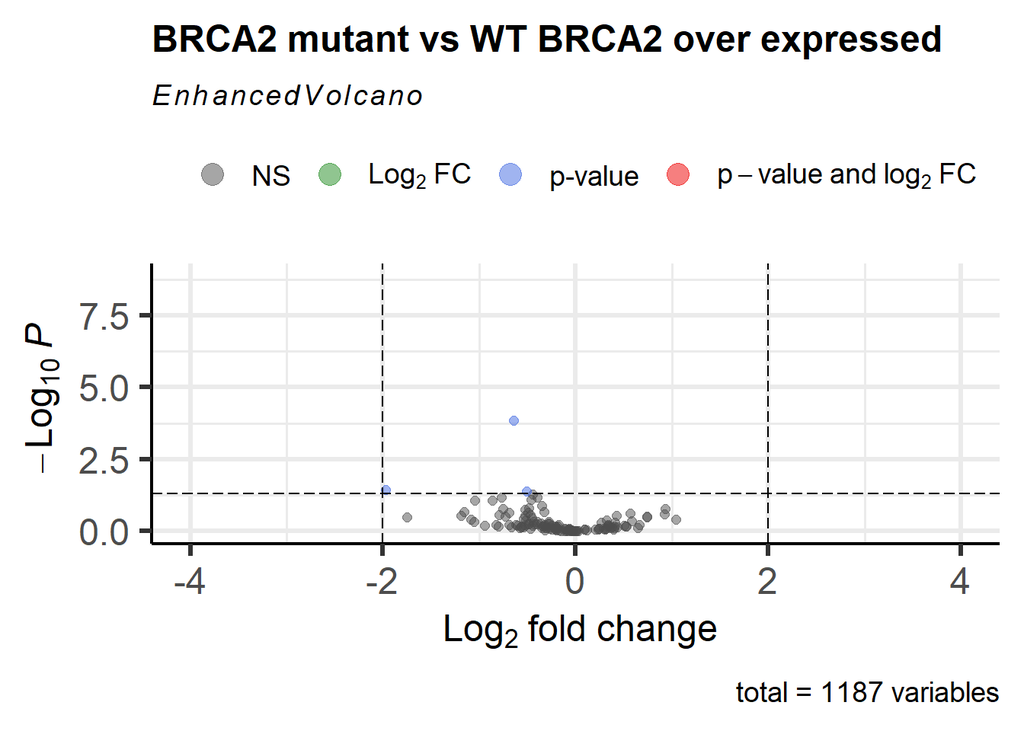

```r
EnhancedVolcano(repetitive_aFB2, lab = rownames(repetitive_aFB2),x ='log2FoldChange',
                y ='padj',xlim =c(-4, 4), title ='BRCA2 mutant vs WT BRCA2 over expressed',
                pCutoff = 0.05 , FCcutoff = 2, pointSize = 2.0,labSize = 3.0 )
```

Analysis for the PAF

```r
aPAF1_R1 = read.table("aPAF1_R1.cntTable",header = T)
aPAF1_R2= read.table("aPAF1_R2.cntTable",header = T)
aPAF1_R3 = read.table("aPAF1_R3.cntTable",header = T)
aPAF1_R4 = read.table("aPAF1_R4.cntTable",header = T)
aPAF1_R5 = read.table("aPAF1_R5.cntTable",header = T)
aPAF1_R6 = read.table("aPAF1_R6.cntTable",header = T)


aPAF1=cbind(aPAF1_R1,aPAF1_R2[,2],aPAF1_R3[,2],aPAF1_R4[,2],aPAF1_R5[,2],aPAF1_R6[,2])

column_name<-c("genes","aPAF1_R1","aPAF2_R2","aPAF3_R3","aPAF4_R4","aPAF5_R5","aPAF6_R6")

colnames(aPAF1)<-column_name

aPAF1$genes<- gsub(aPAF1$genes, pattern = "\\..+", replacement = "")

aPAF1<-aPAF1[!duplicated(aPAF1$genes), ]

aPAF1<- data.frame(aPAF1[,-1], row.names=aPAF1[,1])
```

create the count data by merging BRCA2 mutant and WT PAF1 over expressed

```r
count_aPAF1 <- cbind (a423,aPAF1)
```

create the metadat that has to be loaded for DEseq2

```r
metadata_aPAF1 <- colnames(count_aPAF1)


sample_typePAF<-c("mutant","mutant","mutant","mutant","mutant","mutant",
               "PAF overexpressed","PAF overexpressed","PAF overexpressed",
               "PAF overexpressed","PAF overexpressed","PAF overexpressed")

metadata_aPAF1<-as.data.frame(cbind(metadata_aPAF1,sample_typePAF))
```

conduct DEseq2

```r
dds_PAF <- DESeqDataSetFromMatrix(countData=count_aPAF1,
                              colData=metadata_aPAF1,
                              design=~sample_typePAF)


dds_PAF <-DESeq( dds_PAF )

res_PAF <- results( dds_PAF )

results_PAF <- as.data.frame(res_PAF)


repetitive_PAF<-results_PAF[!grepl("ENSG", rownames(results_PAF)),]
```

create the plot

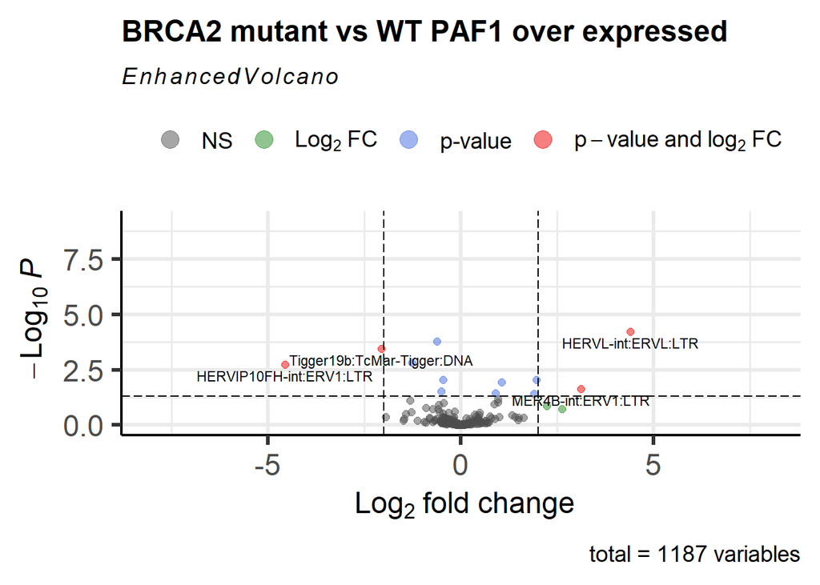

```r
EnhancedVolcano(repetitive_PAF, lab = rownames(repetitive_PAF),x ='log2FoldChange',
                y ='padj',xlim =c(-8, 8), title ='BRCA2 mutant vs WT PAF1 over expressed',
                pCutoff = 0.05 , FCcutoff = 2, pointSize = 2.0,labSize = 3.0 )
```

LTR which are known as retrotransposons are present in the human genome is a form of primary endogenous retrovirus(ERVs). MER4 is a also compramised of LTR ERVs.[1] HERV subfamilies are correlated to type II Inteferone response, CD 8 effector and immune checkpoint activity inferred from the bulk tumor tissue.[2] It is also stated the TEs expression may play a role to adaptive immune infiltration.[2]

In this case the result seem to be less significant to be considered for further analysis.

References:

1.Kojima KK. Human transposable elements in Repbase: genomic footprints from fish to humans. Mob DNA. 2018;9:2. Published 2018 Jan 4.

2.Kong, Y., Rose, C.M., Cass, A.A. et al. Transposable element expression in tumors is associated with immune infiltration and increased antigenicity. Nat Commun 10, 5228 (2019).